# NYC Crime Rates

NYC Crime Rates DATA 607 Final Data Project Stephen Haslett 12/10/2019

```r
library(RCurl)
library(XML)
library(jsonlite)
library(knitr)
library(kableExtra)
library(tidyverse)
library(tidyr)
library(geosphere)
library(leaflet)
library(plyr)
library(tools)
library(prettydoc)
library(ggrepel)
```

## Objective

For this project, I will investigate crime, and crime rates in NYC. The main questions I want to answer are:

1. Which NYC borough has the highest crime rate?
2. Which category of crimes are most common in New York City as a whole?

### Data Sources

The 2 main data sources I will use for this project can be found on NYCOpenData (https://opendata.cityofnewyork.us/data/).

I will explore the “NYPD Arrests Data (Historic)” dataset, and will pull crime statistics from this set in order to explore crime rates in NYC. I will also use the “New York City Population by Borough, 1950 - 2040” dataset in order to calculate crime rates per New York City borough.

The datasets can be found at the following locations:

NYPD Arrests Data (Historic) - https://data.cityofnewyork.us/Public-Safety/NYPD-Arrests-Data-Historic-/8h9b-rp9u

New York City Population by Borough, 1950 - 2040 - https://data.cityofnewyork.us/City-Government/New-York-City-Population-by-Borough-1950-2040/xywu-7bv9

#### Import the Datasets.

The *NYPD Arrests Data (Historic)* csv file is 2.05 GB, so I decided to obtain the data via NYCOpenData’s JSON endpoint to save on memory. The *New York City Population by Borough, 1950 - 2040* csv file is only 4 KB, but for consistency, I also imported this dataset via the JSON endpoint.

```r
crime_data <- fromJSON("https://data.cityofnewyork.us/resource/qgea-i56i.json")
nyc_population <- fromJSON("https://data.cityofnewyork.us/resource/xywu-7bv9.json")
```

### Data Cleansing

#### View the number of columns and rows in the crime_data dataset.

```r
dim(crime_data)
```

```
## [1] 1000   40
```

#### Now look at the data structure, and column names.

```r
str(crime_data)
```

```
## 'data.frame':    1000 obs. of  40 variables:
##  $ cmplnt_num                 : chr  "522575447" "403507361" "631420068" "995609899" ...
##  $ cmplnt_fr_dt               : chr  "2006-08-29T00:00:00.000" "2006-11-05T00:00:00.000" "2006-09-08T00:00:00.000" "2011-12-13T00:00:00.000" ...
##  $ cmplnt_fr_tm               : chr  "13:00:00" "11:00:00" "23:30:00" "18:40:00" ...
##  $ addr_pct_cd                : chr  "43" "66" "106" "79" ...
##  $ rpt_dt                     : chr  "2006-08-30T00:00:00.000" "2006-11-05T00:00:00.000" "2006-09-09T00:00:00.000" "2011-12-13T00:00:00.000" ...
##  $ ky_cd                      : chr  "578" "107" "347" "341" ...
##  $ ofns_desc                  : chr  "HARRASSMENT 2" "BURGLARY" "INTOXICATED & IMPAIRED DRIVING" "PETIT LARCENY" ...
##  $ pd_cd                      : chr  "638" "221" "905" "333" ...
##  $ pd_desc                    : chr  "HARASSMENT,SUBD 3,4,5" "BURGLARY,RESIDENCE,DAY" "INTOXICATED DRIVING,ALCOHOL" "LARCENY,PETIT FROM STORE-SHOPL" ...
##  $ crm_atpt_cptd_cd           : chr  "COMPLETED" "COMPLETED" "COMPLETED" "COMPLETED" ...
##  $ law_cat_cd                 : chr  "VIOLATION" "FELONY" "MISDEMEANOR" "MISDEMEANOR" ...
##  $ boro_nm                    : chr  "BRONX" "BROOKLYN" "QUEENS" "BROOKLYN" ...
##  $ loc_of_occur_desc          : chr  "INSIDE" "INSIDE" "FRONT OF" "INSIDE" ...
##  $ prem_typ_desc              : chr  "RESIDENCE - APT. HOUSE" "RESIDENCE - APT. HOUSE" "STREET" "CHAIN STORE" ...
```

[output cut: 28 more lines]

#### List the dataset column names so we can see which columns are useful for analysis purposes.

```r
colnames(crime_data)
```

```
##  [1] "cmplnt_num"                  "cmplnt_fr_dt"
##  [3] "cmplnt_fr_tm"                "addr_pct_cd"
##  [5] "rpt_dt"                      "ky_cd"
##  [7] "ofns_desc"                   "pd_cd"
##  [9] "pd_desc"                     "crm_atpt_cptd_cd"
## [11] "law_cat_cd"                  "boro_nm"
## [13] "loc_of_occur_desc"           "prem_typ_desc"
## [15] "juris_desc"                  "jurisdiction_code"
## [17] "parks_nm"                    "housing_psa"
## [19] "x_coord_cd"                  "y_coord_cd"
## [21] "susp_race"                   "susp_sex"
## [23] "latitude"                    "longitude"
## [25] "lat_lon"                     "patrol_boro"
## [27] "vic_age_group"               "vic_race"
## [29] "vic_sex"                     ":@computed_region_efsh_h5xi"
## [31] ":@computed_region_f5dn_yrer" ":@computed_region_yeji_bk3q"
## [33] ":@computed_region_92fq_4b7q" ":@computed_region_sbqj_enih"
## [35] "cmplnt_to_dt"                "cmplnt_to_tm"
## [37] "susp_age_group"              "hadevelopt"
## [39] "transit_district"            "station_name"
```

**We don’t need all of the information in the crime_data dataset for our analysis, so we take what we need, and leave what we don’t.**

#### Clean the crime_data dataset so that we can use it for our analysis.

```r
# Extract the columns containing the data that we need.
crime_data_refined <- select(crime_data, rpt_dt, ofns_desc, pd_desc, ofns_desc, law_cat_cd, boro_nm, addr_pct_cd, latitude, longitude, lat_lon)

# Remove NAs from the data.
sapply(crime_data_refined, function(x) sum(is.na(x)))
```

```
##      rpt_dt   ofns_desc     pd_desc  law_cat_cd     boro_nm addr_pct_cd
##           0           9           0           0           2           0
##    latitude   longitude     lat_lon
##           9           9          18
```

```r
clean_crime_data <- na.omit(crime_data_refined)
sapply(clean_crime_data, function(x) sum(is.na(x)))
```

```
##      rpt_dt   ofns_desc     pd_desc  law_cat_cd     boro_nm addr_pct_cd
##           0           0           0           0           0           0
##    latitude   longitude     lat_lon
##           0           0           0
```

```r
summary(clean_crime_data)
```

```
##     rpt_dt           ofns_desc           pd_desc
##  Length:980         Length:980         Length:980
##  Class :character   Class :character   Class :character
##  Mode  :character   Mode  :character   Mode  :character
##   law_cat_cd          boro_nm          addr_pct_cd
##  Length:980         Length:980         Length:980
##  Class :character   Class :character   Class :character
##  Mode  :character   Mode  :character   Mode  :character
##    latitude          longitude
##  Length:980         Length:980
##  Class :character   Class :character
##  Mode  :character   Mode  :character
##   lat_lon.latitude   lat_lon.longitude
##  Length:980          Length:980
##  Class :character    Class :character
##  Mode  :character    Mode  :character
```

#### Look at a sample of the clean data.

```r
sample_n(clean_crime_data, 5)
```

```
##                    rpt_dt                      ofns_desc
## 1 2010-06-01T00:00:00.000                  GRAND LARCENY
## 2 2009-07-27T00:00:00.000  OFF. AGNST PUB ORD SENSBLTY &
## 3 2006-08-18T00:00:00.000        MISCELLANEOUS PENAL LAW
## 4 2007-09-12T00:00:00.000                  HARRASSMENT 2
## 5 2006-11-25T00:00:00.000 CRIMINAL MISCHIEF & RELATED OF
##                                                  pd_desc  law_cat_cd
## 1 LARCENY,GRAND FROM BUILDING (NON-RESIDENCE) UNATTENDED      FELONY
## 2                                AGGRAVATED HARASSMENT 2 MISDEMEANOR
## 3                                    CRIMINAL CONTEMPT 1      FELONY
## 4                                  HARASSMENT,SUBD 3,4,5   VIOLATION
## 5                         MISCHIEF, CRIMINAL 4, OF MOTOR MISDEMEANOR
##     boro_nm addr_pct_cd     latitude     longitude lat_lon.latitude
## 1 MANHATTAN           1 40.703684905 -74.009667273     40.703684905
## 2 MANHATTAN          17 40.755516375 -73.970988622     40.755516375
## 3  BROOKLYN          84 40.691094994 -73.996074542     40.691094994
## 4     BRONX          42 40.832036889 -73.886736442     40.832036889
## 5  BROOKLYN          83  40.70685174 -73.919028249      40.70685174
##   lat_lon.longitude
## 1     -74.009667273
## 2     -73.970988622
## 3     -73.996074542
## 4     -73.886736442
## 5     -73.919028249
```

### NYC Population Dataset

#### View the number of columns and rows in the nyc_population dataset.

```r
dim(nyc_population)
```

```
## [1]  6 22
```

#### Look at the data structure, and column names.

```r
str(nyc_population)
```

```
## 'data.frame':    6 obs. of  22 variables:
##  $ age_group                    : chr  "Total Population" "Total Population" "Total Population" "Total Population" ...
##  $ borough                      : chr  "NYC Total" "   Bronx" "   Brooklyn" "   Manhattan" ...
##  $ _1950                        : chr  "7891957" "1451277" "2738175" "1960101" ...
##  $ _1950_boro_share_of_nyc_total: chr  "100.00" "18.39" "34.70" "24.84" ...
##  $ _1960                        : chr  "7781984" "1424815" "2627319" "1698281" ...
##  $ _1960_boro_share_of_nyc_total: chr  "100.00" "18.31" "33.76" "21.82" ...
##  $ _1970                        : chr  "7894862" "1471701" "2602012" "1539233" ...
##  $ _1970_boro_share_of_nyc_total: chr  "100.00" "18.64" "32.96" "19.50" ...
##  $ _1980                        : chr  "7071639" "1168972" "2230936" "1428285" ...
##  $ _1980_boro_share_of_nyc_total: chr  "100.00" "16.53" "31.55" "20.20" ...
##  $ _1990                        : chr  "7322564" "1203789" "2300664" "1487536" ...
##  $ _1990_boro_share_of_nyc_total: chr  "100.00" "16.44" "31.42" "20.31" ...
##  $ _2000                        : chr  "8008278" "1332650" "2465326" "1537195" ...
##  $ _2000_boro_share_of_nyc_total: chr  "100.00" "16.64" "30.78" "19.20" ...
##  $ _2010                        : chr  "8242624" "1385108" "2552911" "1585873" ...
##  $ _2010_boro_share_of_nyc_total: chr  "100.00" "16.80" "30.97" "19.24" ...
##  $ _2020                        : chr  "8550971" "1446788" "2648452" "1638281" ...
##  $ _2020_boro_share_of_nyc_total: chr  "100.00" "16.92" "30.97" "19.16" ...
##  $ _2030                        : chr  "8821027" "1518998" "2754009" "1676720" ...
##  $ _2030_boro_share_of_nyc_total: chr  "100.00" "17.22" "31.22" "19.01" ...
##  $ _2040                        : chr  "9025145" "1579245" "2840525" "1691617" ...
##  $ _2040_boro_share_of_nyc_total: chr  "100.00" "17.50" "31.47" "18.74" ...
```

#### List the dataset column names.

```r
colnames(nyc_population)
```

```
##  [1] "age_group"                     "borough"
##  [3] "_1950"                         "_1950_boro_share_of_nyc_total"
##  [5] "_1960"                         "_1960_boro_share_of_nyc_total"
##  [7] "_1970"                         "_1970_boro_share_of_nyc_total"
##  [9] "_1980"                         "_1980_boro_share_of_nyc_total"
## [11] "_1990"                         "_1990_boro_share_of_nyc_total"
## [13] "_2000"                         "_2000_boro_share_of_nyc_total"
## [15] "_2010"                         "_2010_boro_share_of_nyc_total"
## [17] "_2020"                         "_2020_boro_share_of_nyc_total"
## [19] "_2030"                         "_2030_boro_share_of_nyc_total"
## [21] "_2040"                         "_2040_boro_share_of_nyc_total"
```

#### Clean the nyc_population dataset.

```r
# We only need 2 columns from the table (Borough and Population).
nyc_population_refined <- select(nyc_population, borough, '_2020')

# Remove NAs from the data.
sapply(nyc_population_refined, function(x) sum(is.na(x)))
```

```
## borough   _2020
##       0       0
```

```r
clean_pop_data <- na.omit(nyc_population_refined)
sapply(clean_pop_data, function(x) sum(is.na(x)))
```

```
## borough   _2020
##       0       0
```

```r
# Get rid of the NYC Total population row as we don't need it.
clean_pop_data = clean_pop_data[-1,]

# Rename the columns.
colnames(clean_pop_data) <- c('Borough', 'Population')

sample_n(clean_pop_data, 5)
```

```
##            Borough Population
## 1           Queens    2330295
## 2         Brooklyn    2648452
## 3    Staten Island     487155
## 4            Bronx    1446788
## 5        Manhattan    1638281
```

### Data Analysis

#### Crime Frequency by Borough

```r
# Count the occurences of a borough name to give us an idea of the crime rate in the borough.
crimes_per_borough <- table(clean_crime_data$boro_nm)
head(crimes_per_borough)
```

```
##
##         BRONX      BROOKLYN     MANHATTAN        QUEENS STATEN ISLAND
##           211           308           233           176            52
```

#### Create a new dataframe that contains a population column for each borough.

```r
crimes_dataframe <- as.data.frame(crimes_per_borough, stringsAsFactors=FALSE)
population_dataframe <- as.data.frame(clean_pop_data, stringsAsFactors=FALSE)

# Add column names to the crimes_dataframe.
colnames(crimes_dataframe) <- c('Borough', 'Crimes')

# Convert borough names to title case form so that we can join on 'Borough'
# with the population_dataframe.
crimes_dataframe$Borough <- str_to_title(crimes_dataframe$Borough)

# Join the 2 tables together.
crimes_population <- join(crimes_dataframe, population_dataframe, by = 'Borough', type = 'right')
crimes_population$Crimes <- crimes_dataframe$Crimes

kable(crimes_population, "html", escape = F) %>%
  kable_styling("striped", full_width = T) %>%
  column_spec(1, bold = T)
```

| Borough | Crimes | Population |
| --- | --- | --- |
| Bronx | 211 | 1446788 |
| Brooklyn | 308 | 2648452 |
| Manhattan | 233 | 1638281 |
| Queens | 176 | 2330295 |
| Staten Island | 52 | 487155 |

#### Calculate the crime rate for each Borough, and add a CrimeRate column to the crimes_population dataframe.

```r
crime_rate <- as.numeric(crimes_population$Crimes) / as.numeric(crimes_population$Population) * 100000
crimes_population$CrimeRate <- round(as.numeric(format(crime_rate, scientific = FALSE)), 2)
kable(crimes_population, "html", escape = F) %>%
  kable_styling("striped", full_width = T) %>%
  column_spec(1, bold = T)
```

| Borough | Crimes | Population | CrimeRate |
| --- | --- | --- | --- |
| Bronx | 211 | 1446788 | 14.58 |
| Brooklyn | 308 | 2648452 | 11.63 |
| Manhattan | 233 | 1638281 | 14.22 |
| Queens | 176 | 2330295 | 7.55 |
| Staten Island | 52 | 487155 | 10.67 |

#### Plot a bar graph displaying the crime rates for each borough.

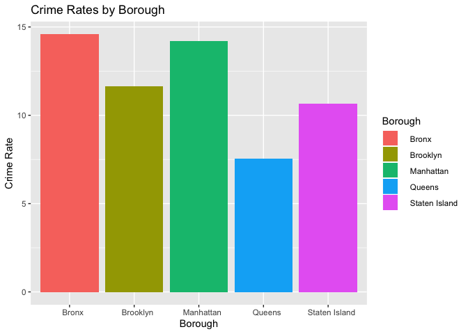

```r
crime_by_borough_plot <-ggplot(crimes_population, aes(x = Borough, y = CrimeRate, fill = Borough)) +
  geom_bar(stat = 'identity') +
      labs(title = 'Crime Rates by Borough',
         x = 'Borough',
         y = 'Crime Rate')


crime_by_borough_plot
```

### New York City crime by category

```r
cat_nyc <- select(clean_crime_data, law_cat_cd)

crime_category_table <- table(cat_nyc$law_cat_cd)
crime_category_table <- sort(crime_category_table, decreasing = TRUE)

crime_by_category <- as.data.frame(crime_category_table, stringsAsFactors = FALSE)
colnames(crime_by_category) <- c("Category", "Frequency")
crime_by_category$Percentage <- crime_by_category$Frequency / sum(crime_by_category$Frequency) * 100
crime_by_category
```

```
##      Category Frequency Percentage
## 1 MISDEMEANOR       572   58.36735
## 2      FELONY       291   29.69388
## 3   VIOLATION       117   11.93878
```

### Bar graph displaying arrest frequency by crime category in NYC.

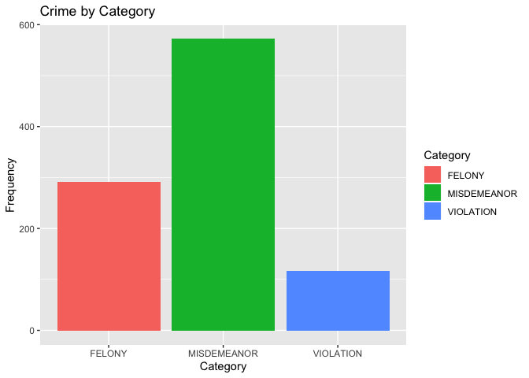

```r
crime_by_category_plot <-ggplot(crime_by_category, aes(x = Category, y = Frequency, fill = Category)) +
  geom_bar(stat="identity") +
        labs(title = 'Crime by Category',
         x = 'Category',
         y = 'Frequency')

crime_by_category_plot
```

### Pie chart displaying arrest frequency by crime category in NYC.

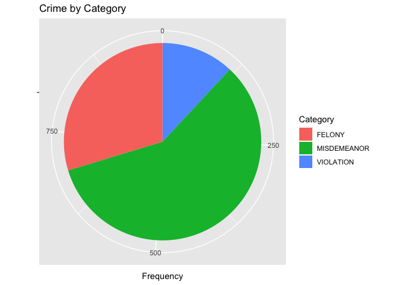

```r
crime_category_pie_chart <-ggplot(crime_by_category, aes(x = '', y = Frequency, fill = Category)) +
  geom_bar(stat ='identity') +
  coord_polar(theta = 'y') +
  scale_x_discrete('') +
  labs(title = 'Crime by Category',
    x = 'Category',
    y = 'Frequency')

crime_category_pie_chart
```

These statistics make sense as felonies are less likely crimes, misdemeanors are less serious crimes, but often result in arrest, and violations rarely lead to arrest.

### Crimes Leading to The Least Arrests in NYC

```r
least_crimes <- sort(table(clean_crime_data$pd_desc), decreasing = TRUE)
least_crimes <- data.frame(least_crimes[least_crimes < 10])
colnames(least_crimes) <- c('Crime', 'Frequency')
least_crimes$Percentage <- least_crimes$Frequency / sum(least_crimes$Frequency) * 100

kable(least_crimes, "html", escape = F) %>%
  kable_styling("striped", full_width = T) %>%
  column_spec(1, bold = T)
```

| Crime | Frequency | Percentage |
| --- | --- | --- |
| FORGERY,ETC.-MISD. | 9 | 4.109589 |
| FRAUD,UNCLASSIFIED-FELONY | 8 | 3.652968 |
| LARCENY,GRAND BY THEFT OF CREDIT CARD | 8 | 3.652968 |
| LEAVING SCENE-ACCIDENT-PERSONA | 8 | 3.652968 |
| MISCHIEF, CRIMINAL 3 & 2, OF M | 8 | 3.652968 |
| FORGERY,ETC.,UNCLASSIFIED-FELO | 7 | 3.196347 |
| FRAUD,UNCLASSIFIED-MISDEMEANOR | 6 | 2.739726 |
| VIOLATION OF ORDER OF PROTECTI | 6 | 2.739726 |
| BURGLARY,COMMERCIAL,NIGHT | 5 | 2.283105 |
| CONTROLLED SUBSTANCE,POSSESS. | 5 | 2.283105 |
| LARCENY,GRAND BY BANK ACCT COMPROMISE-REPRODUCED CHECK | 5 | 2.283105 |
| MISCHIEF,CRIMINAL, UNCL 2ND | 5 | 2.283105 |
| RESISTING ARREST | 5 | 2.283105 |
| BRIBERY,PUBLIC ADMINISTRATION | 4 | 1.826484 |
| BURGLARY,RESIDENCE,NIGHT | 4 | 1.826484 |
| LARCENY,PETIT OF VEHICLE ACCES | 4 | 1.826484 |
| MARIJUANA, POSSESSION | 4 | 1.826484 |
| ROBBERY,PUBLIC PLACE INSIDE | 4 | 1.826484 |
| SEXUAL ABUSE 3,2 | 4 | 1.826484 |
| THEFT OF SERVICES, UNCLASSIFIE | 4 | 1.826484 |
| AGGRAVATED HARASSMENT 1 | 3 | 1.369863 |
| ARSON, MOTOR VEHICLE 1 2 3 & 4 | 3 | 1.369863 |
| BURGLARY,RESIDENCE,UNKNOWN TIM | 3 | 1.369863 |
| CHILD, ENDANGERING WELFARE | 3 | 1.369863 |
| LARCENY,GRAND BY ACQUIRING LOS | 3 | 1.369863 |
| LARCENY,GRAND OF MOTORCYCLE | 3 | 1.369863 |
| MARIJUANA, SALE 4 & 5 | 3 | 1.369863 |
| RAPE 1 | 3 | 1.369863 |
| STOLEN PROPERTY 3,POSSESSION | 3 | 1.369863 |
| TRAFFIC,UNCLASSIFIED MISDEMEAN | 3 | 1.369863 |

[output cut: 56 more lines]

## Conclusion

The number of arrests for low level crimes are consistently low throughout this report. This would suggest that such crimes often go unreported, or they are so low level that they do not warrent arrest. The fact that misdemeanors lead to the most arrests is of no surprise. Such crimes are low level, but they lead to arrest. The fact that they are low level probably means people are more likely to commit these crimes with little effort to hide their actions.

When it comes to safe boroughs in New York, it appears that Queens is the safest borough, followed by Staten Island. The most dangerous borough is the Bronx, followed by Manhattan.

I would not have expected Manhattan to have a high crime rate, so given more time, this would have been an interesting point to explore further. Either there are interesting reason for this lurking below the surface, or the data is somehow skewed.